# Introduction to pvEBayes

## spontaneous reporting systems data mining

Contemporary drug postmarketing surveillance largely relies on the collection of spontaneous reports of suspected adverse drug events from pharmaceutical companies, healthcare professionals, and patients. These reports are curated and stored in spontaneous reporting systems (SRS), usually organized as a large frequency table for downstream data analysis. We consider an SRS dataset cataloging adverse event (AE) reports on $I$ AE rows across $J$ drug columns. Let $N_{ij}$ denote the number of reported cases for the $i$-th AE and the $j$-th drug, where $i = 1,..., I$ and $j = 1,..., J$. Therefore, AE-drug pairwise occurrences from the AE-reports are summarized into an $I \times J$ contingency table, where the $(i,j)$-th cell catalogs the observed count $N_{ij}$ indicating the number of cases involving $i$-th AE and the $j$-th drug.

Current disproportionality analysis mainly focuses on *signal detection* which seeks to determine whether the observation $N_{ij}$ is substantially greater than the corresponding null baseline $E_{ij}$. Or equivalently, its signal strength $\lambda_{ij}$ is significantly greater than 1.

In addition to *signal detection*, Tan et al. (*Stat. in Med.*, 2025) broaden the role of disproportionality to *signal strength estimation*. The use of the flexible non-parametric empirical Bayes models enables more nuanced empirical Bayes posterior inference (signal strength $\{\lambda_{ij}\}$ estimation and uncertainty quantification). This allows researchers to distinguish AE-drug pairs that would appear similar under a binary signal detection framework. For example, the AE-drug pairs with signal strengths of 1.5 and 4.0 could both be significantly greater than 1 and detected as a signal. Such differences in signal strength may have distinct implications in medical and clinical contexts.

Methods implemented in this package assumes the observed count $N_{ij}$ conditional on $E_{ij}$ is that
$$\begin{equation}
\label{eqn:model-poisson-likelihood}
N_{ij} \mid E_{ij} \sim \operatorname{Poisson}(E_{ij}\lambda_{ij}), \
N_{ij} = 0, 1, 2 \dots,
\end{equation}$$
where the parameter $\lambda_{ij} \geq 0$ is the relative reporting ratio, the signal strength, for the $(i, j)$-th pair measuring the ratio of the actual expected count arising due to dependence to the null baseline expected count. Therefore, $\{\lambda_{ij}\}$ are our key parameters of interest. A large $\lambda_{ij}$ indicates a strong association between a drug and an AE.

Let $g$ be a prior density function for signal strength parameters for all AE-drug pairs: $\lambda_{ij} \sim g$. Then, in the context of the Poisson model, the marginal probability mass function of $N_{ij}$ is given by:
$$p(N_{ij}) = \int_0^{\infty} g(\lambda_{ij}) \ f_{\text{pois}}(N_{ij}
\mid \lambda_{ij}E_{ij}) \ d\lambda_{ij},$$
where $f_{\text{pois}}(N_{ij} \mid \lambda_{ij})$ is the probability mass function of a Poisson random variable with mean $\lambda_{ij}$ evaluated at $N_{ij}$. Under the empirical Bayes framework, the prior distribution is consequently estimated from the data by maximizing the log marginal likelihood:
$$\hat g = \mathop{\arg \max}\limits_{g} \sum_{i=1}^I \sum_{j=1}^J \log
p(N_{ij}).$$
Then, the estimated empirical Bayes posterior density of $\lambda_{ij}$ given $N_{ij}$ is:
$$\hat{\text{p}}(\lambda_{ij} \mid N_{ij}) = \frac{\hat g(\lambda_{ij})
f_{\text{pois}}(N_{ij} \mid \lambda_{ij}
E_{ij})}{\hat{\text{p}}(N_{ij})}, \ \lambda_{ij} > 0,$$
where $\hat{\text{p}}(N_{ij}) = \int_0^{\infty} \hat g(\lambda_{ij})f_{\text{pois}}(N_{ij}\mid \lambda_{ij}E_{ij}) \ d\lambda_{ij}$.

All empirical Bayes models implemented in ‘pvEBayes’ share the structure described above; they differ by their assumptions on the prior distribution. Implemented methods include the Gamma-Poisson Shrinker (GPS), Koenker-Mizera (KM) method, Efron’s nonparametric empirical Bayes approach, the K-gamma model, and the general-gamma model. The selection of the prior distribution is critical in Bayesian analysis. The GPS model uses a gamma mixture prior by assuming the signal/non-signal structure in SRS data. However, in real-world setting, signal strengths ${(\lambda_{ij})}$ are often heterogeneous and thus follows a multi-modal distribution, making it difficult to assume a parametric prior. Non-parametric empirical Bayes models (KM, Efron, K-gamma and general-gamma) address this challenge by utilizing a flexible prior with a general mixture form and estimating the prior distribution in a data-driven way.

The KM method has an existing implementation in the `REBayes` package, but it relies on Mosek, a commercial convex optimization solver, which may limit accessibility due to licensing issues. The `pvEBayes` package provides an alternative fully open-source implementation of the KM method using `CVXR`. Efron’s method also has a general nonparametric empirical Bayes implementation in the `deconvolveR` package; however, that implementation does not support an exposure or offset parameter in the Poisson model, which corresponds to the expected null value ${E_{ij}}$. In `pvEBayes`, the implementation of Efron’s method is adapted and modified from `deconvolveR` to support ${E_{ij}}$ in the Poisson model. In addition, this package implements the novel bi-level Expectation Conditional Maximization (ECM) algorithm proposed by Tan et al. (2025) for efficient parameter estimation in gamma mixture prior based models mentioned above.

Package ‘pvEBayes’ provides a suite of streamlined tools for effectively fitting these models to the spontaneous reporting system (SRS) frequency tables, extracting summaries, performing hyperparameter tuning, and generating graphical summaries (eye plots and heatmaps) for signal detection and estimation. In the following we provide an example, borrowed from Tan et al. (*arxiv*, 2025), of SRS data analyzing with ‘pvEBayes’.

## Analyzing FDA statin SRS data with pvEBayes

```r
library(pvEBayes)
library(ggplot2)

set.seed(1)
# load the SRS data
data("statin2025_44")

# show the first 6 rows
head(statin2025_44)
```

```
#>                                        Atorvastatin Fluvastatin Lovastatin
#> ACUTE KIDNEY INJURY                            1132          23         23
#> ANURIA                                           46           0          0
#> BLOOD CALCIUM DECREASED                          51           2          0
#> BLOOD CREATINE PHOSPHOKINASE ABNORMAL            19           0          0
#> BLOOD CREATINE PHOSPHOKINASE INCREASED          624          21          4
#> BLOOD CREATININE ABNORMAL                        11           0          0
#>                                        Pravastatin Rosuvastatin Simvastatin
#> ACUTE KIDNEY INJURY                            153         1141         453
#> ANURIA                                           1           56          29
#> BLOOD CALCIUM DECREASED                          3          877           6
#> BLOOD CREATINE PHOSPHOKINASE ABNORMAL            0           11           1
#> BLOOD CREATINE PHOSPHOKINASE INCREASED          41          557         216
#> BLOOD CREATININE ABNORMAL                        0           32           6
#>                                        Other_drugs
#> ACUTE KIDNEY INJURY                         192114
#> ANURIA                                        7079
#> BLOOD CALCIUM DECREASED                      33175
#> BLOOD CREATINE PHOSPHOKINASE ABNORMAL          133
#> BLOOD CREATINE PHOSPHOKINASE INCREASED       17203
#> BLOOD CREATININE ABNORMAL                     2645
```

### Fit the general-gamma model

Our interest lies in finding the most important adverse events and estimating the corresponding signal strength of these 6 statin drugs. These are achieved by fitting empirical Bayes models with pvEBayes() to the SRS data. We begin by fitting the general-gamma model to this dataset. Other models mentioned above could be used by modifying the ‘model’ argument. “general-gamma” method has a hyperparameter $\alpha \in [0,1]$. Small $\alpha$ encourages shrinkage on mixture weights of the estimated prior distribution. See Tan et al. (2025, ) for further details. For illustration, we fit the model with a fixed hyperparameter value of $\alpha = 0.5$ using the pvEBayes() function.

```r
gg_given_alpha <- pvEBayes(statin2025_44,
  model = "general-gamma",
  alpha = 0.5,
  maxi = 200,
  tol_ecm = 1e-4  #default value
)
```

```
#> ℹ Fitting general-gamma model...✔ Fitting general-gamma model... [467ms]
#> ℹ Generating 1000 posterior draws...✔ Generating 1000 posterior draws... [36ms]
#> Object of class 'pvEBayes'
#>
#> General-gamma model with hyperparameter alpha = 0.5.
#> Estimated prior is a mixture of 18 gamma distributions.
#>
#> Running time of the general-gamma model fitting: 0.4778 seconds.
#> Optimizer convergence: successful.
#> Running time for posterior draws
#> (1000 signal strength posterior draws per AE-drug pair):0.0521 seconds.
#>
#> Extract estimated prior parameters, discovered signals
#> and signal strength posterior draws using `summary()`.
```

```r
gg_given_alpha$iter
```

```
#> [1] 167
```

The convergence criterion in `pvEBayes()` is based on the relative change in the log likelihood between consecutive iterations. In this example, the algorithm stopped after satisfying the convergence criterion. This is also reflected in the printed model fitting message, where the optimizer convergence status is reported as successful. We can inspect the number of iterations used by the fitting algorithm by `gg_given_alpha\$iter`. In this fit, convergence was achieved after 167 iterations.

The next example illustrates a case in which the algorithm stops because it reaches the maximum number of iterations. Here, we use a smaller convergence tolerance.

```r
gg_given_alpha2 <- pvEBayes(statin2025_44,
  model = "general-gamma",
  alpha = 0.5,
  maxi = 200,
  tol_ecm = 1e-8  #smaller tolerance for convergence
)
```

```
#> ℹ Fitting general-gamma model...✔ Fitting general-gamma model... [569ms]
#> ℹ Generating 1000 posterior draws...✔ Generating 1000 posterior draws... [40ms]
#> Object of class 'pvEBayes'
#>
#> General-gamma model with hyperparameter alpha = 0.5.
#> Estimated prior is a mixture of 18 gamma distributions.
#>
#> Running time of the general-gamma model fitting: 0.5773 seconds.
#> Optimizer convergence: not achieved.
#> Running time for posterior draws
#> (1000 signal strength posterior draws per AE-drug pair):0.0487 seconds.
#>
#> Extract estimated prior parameters, discovered signals
#> and signal strength posterior draws using `summary()`.
```

```r
gg_given_alpha2$iter
```

```
#> [1] 200
```

In this case, the algorithm stopped after reaching the specified maximum of 200 iterations. Accordingly, the printed model fitting message reports that optimizer convergence was not achieved.

### Extracting results

```r
summary(gg_given_alpha)
```

```
#> Posterior probabilities with default threshold parameters is provided. To specify threshold parameter, see 'get_posterior_prob()'.
#> Object of class 'pvEBayes'
#>
#> General-gamma model with hyperparameter alpha = 0.5.
#> Estimated prior is a mixture of 18 gamma distributions.
#>
#> Running time of the general-gamma model fitting: 0.4778 seconds.
#> Optimizer convergence: successful.
#> Running time for posterior draws
#> (1000 signal strength posterior draws per AE-drug pair):0.0521 seconds.
#>
#> Extract estimated prior parameters, discovered signals
#> and signal strength posterior draws using `summary()`.
#>                       AE         drug     N      E post_prob        q05
#>                   <char>       <char> <int>  <num>     <num>      <num>
#>   1: Acute Kidney Injury Atorvastatin  1132 532.74     1.000  2.0973713
#>   2: Acute Kidney Injury  Fluvastatin    23  50.91     0.000  0.4355592
#>   3: Acute Kidney Injury   Lovastatin    23   4.97     1.000  2.7676163
#>   4: Acute Kidney Injury  Pravastatin   153  74.39     1.000  2.0965864
#>   5: Acute Kidney Injury Rosuvastatin  1141 424.95     1.000  2.7297708
#>  ---
#> 311:   Tendon Discomfort   Lovastatin     0   0.01     0.607  0.1060236
#> 312:   Tendon Discomfort  Pravastatin     0   0.08     0.522  0.1071040
#> 313:   Tendon Discomfort Rosuvastatin    10   0.45     1.000 12.2678370
#> 314:   Tendon Discomfort  Simvastatin     0   0.31     0.410  0.0170078
#> 315:   Tendon Discomfort  Other_drugs   205 205.00     0.498  0.9842906
#>             q50        q95
#>           <num>      <num>
#>   1:  2.1173546  2.1389235
#>   2:  0.4464949  0.4570815
#>   3:  3.8894362  6.2794596
#>   4:  2.1177660  2.1379450
#>   5:  2.7489835  2.7712210
#>  ---
#> 311:  1.0097489 23.2043456
#> 312:  1.0021966  8.4802357
#> 313: 23.2032496 23.2074071
#> 314:  0.9950467  3.8685038
#> 315:  1.0008954  1.0165167
```

```r
gg_given_alpha_detected_signal <- summary(gg_given_alpha,
  return = "detected signal"
)
```

```
#> Signal detection result with default threshold parameters is provided. To specify threshold parameter, see 'get_posterior_prob()'.
```

```r
sum(gg_given_alpha_detected_signal)
```

```
#> [1] 107
```

The return argument specifies which component the summary function should return. Valid options include: “prior parameters”, “likelihood”, “detected signal”, “posterior draws” and “posterior draws long format”. If it is set to NULL (default), a summary table will be returned (see ‘summary_table_pvEBayes()’). The ‘summary()’ method reports detected signals using the default cutoff value and threshold:
$$\begin{equation}
p(\lambda_{ij} > 1.001 \mid N_{ij}) > 0.95
\end{equation}$$
Users can customize signal detection with both the cutoff and the posterior probability threshold through the ‘get_posterior_prob()’ function. For example, the code below identifies signals using a cutoff value of `1.01` and a posterior probability threshold of `0.99`:

```r
gg_customize_detected_signal <- get_posterior_prob(gg_given_alpha,
                                                     cutoff_signal = 1.01) > 0.99
sum(gg_customize_detected_signal)
```

```
#> [1] 95
```

### Hyperparameter tuning

In this package, we suggest tuning the general-gamma model by AIC or BIC, which can be accessed through ‘AIC()’ or ‘BIC()’ functions, as shown below:

```r
AIC(gg_given_alpha)
```

```
#> [1] 3796.813
```

```r
BIC(gg_given_alpha)
```

```
#> [1] 3999.452
```

In practice, one can specify a list of candidate $\alpha$ values, fit the general-gamma model for each, compute the corresponding AIC or BIC, and select the model with the lowest AIC or BIC. Instead of manually doing so, one can use the ‘pvEBayes_tune()’ function, which implements these steps. The relevant code is given below:

```r
gg_tune_statin44 <- pvEBayes_tune(statin2025_44,
  model = "general-gamma",
  alpha_vec = c(0, 0.1, 0.3, 0.5, 0.7, 0.9),
  use_AIC = TRUE
)
```

```
#> The alpha value selected under AIC is 0.5,
#> The alpha value selected under BIC is 0.
#>   alpha      AIC      BIC num_mixture
#> 1   0.0 3803.082 3960.690          14
#> 2   0.1 3799.012 3990.393          17
#> 3   0.3 3798.874 4001.513          18
#> 4   0.5 3796.813 3999.452          18
#> 5   0.7 3824.280 4083.208          23
#> 6   0.9 3912.529 4340.322          38
```

The `pvEBayes_tune()` also support hyperparameter $(p, c_0)$ tuning for `efron` model. These two hyperparameters control the complexity of the nonparametric empirical Bayes model (See Efron (2016, *Biometrika*) for further details). As a result, the tuning is performed by a two-dimensional grid search over the candidate values supplied through `p_vec` and `c0`. Because all combinations of these values are evaluated, this step can be time-consuming when large candidate grids are used.

```r
e_tune_statin44 <- pvEBayes_tune(statin2025_44,
  model = "efron",
  p_vec = c(40, 60, 80),
  c0 = c(0.001, 0.01, 0.1),
  use_AIC = TRUE
)
```

```
#> The hyperparameters selected under AIC is (p = 80, c0 = 0.1),
#> The hyperparameters selected under BIC is (p = 80, c0 = 0.1).,
#>    p    c0      AIC      BIC
#> 1 40 0.001 2802.602 2915.593
#> 2 60 0.001 2796.279 2937.171
#> 3 80 0.001 2808.362 2983.046
#> 4 40 0.010 2804.672 2913.968
#> 5 60 0.010 2798.204 2937.983
#> 6 80 0.010 2807.676 2972.522
#> 7 40 0.100 2841.045 2943.353
#> 8 60 0.100 2789.335 2865.166
#> 9 80 0.100 2779.490 2858.647
```

```r
e_tune_statin44
```

```
#> Object of class 'pvEBayes'
#>
#> efron model is fitted with hyperparameters (p = 80, c0 = 0.1).
#>
#> Running time of the efron model fitting: 0.4261 seconds.
#> Optimizer convergence: successful.
#> Running time for posterior draws
#> (1000 signal strength posterior draws per AE-drug pair):0.1117 seconds.
#>
#> Extract estimated prior parameters, discovered signals
#> and signal strength posterior draws using `summary()`.
```

## Visualization

In addition, ‘pvEBayes’ has implemented visual summary methods for both signal detection and estimation, which are heatmap and eyeplot. These plot functions can be accessed through the ‘plot()’ with argument type = “heatmap” or type = “eyeplot”.

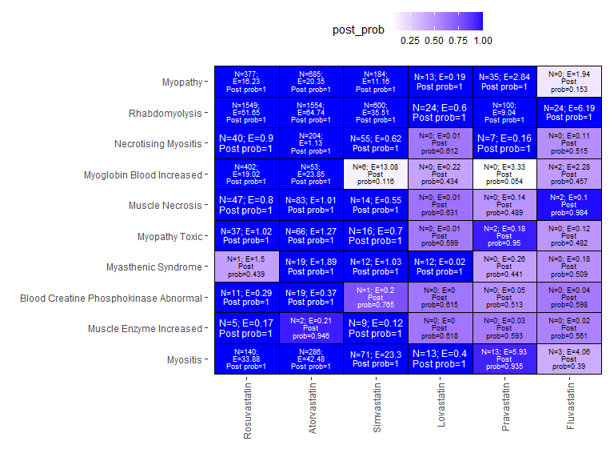

```r
heatmap_gg_tune_statin44 <- plot(gg_tune_statin44,
  type = "heatmap",
  num_top_AEs = 10,
  cutoff_signal = 1.001
)

heatmap_gg_tune_statin44 +
  theme(
    legend.position = "top"
  )
```

The above heatmap visualizes the signal detection result for the fitted general-gamma model. For each AE-drug combination, the number of reports (N), the estimated null value (E), and the estimated empirical Bayes posterior probability of being a signal are given. A deeper blue color indicates stronger evidence for a signal.

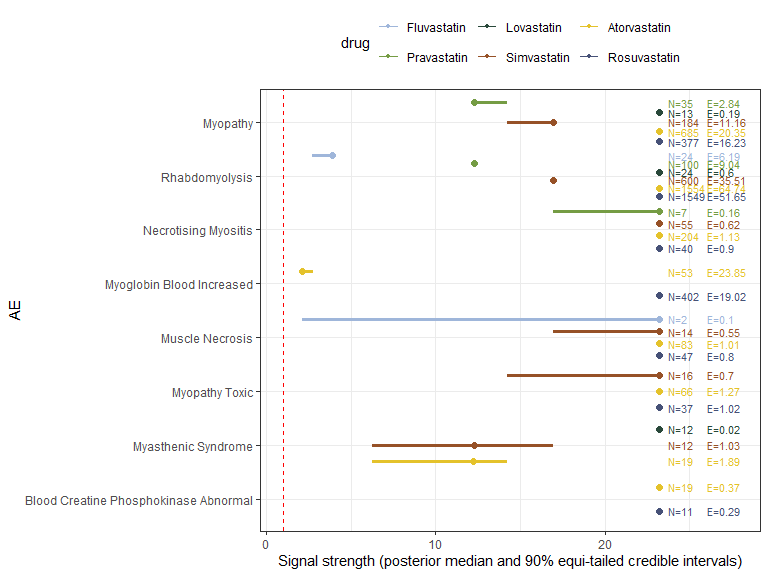

```r
eyeplot_gg_tune_statin44 <- plot(gg_tune_statin44,
  type = "eyeplot",
  num_top_AEs = 8,
  N_threshold = 1,
  log_scale = FALSE,
  text_shift = 2.3,
  text_size = 3,
  x_lim_scalar = 1.2
)

eyeplot_gg_tune_statin44 +
  theme(
    legend.position = "top"
  )
```

# References

Tan Y, Markatou M and Chakraborty S. Flexible Empirical Bayesian Approaches to Pharmacovigilance for Simultaneous Signal Detection and Signal Strength Estimation in Spontaneous Reporting Systems Data. *Statistics in Medicine*. 2025; 44: 18-19, https://doi.org/10.1002/sim.70195.

Tan Y, Markatou M and Chakraborty S. pvEBayes: An R Package for Empirical Bayes Methods in Pharmacovigilance. *arXiv*:2512.01057 (stat.AP). https://doi.org/10.48550/arXiv.2512.01057

Tan Y, Markatou M, Chakraborty S. A Review of Statistical Methods for Spontaneous Reporting System Data Mining: Signal Detection and Beyond. *arXiv*:2604.18898 (stat.AP). https://doi.org/10.48550/arXiv.2604.18898

Koenker R, Mizera I. Convex Optimization, Shape Constraints, Compound Decisions, and Empirical Bayes Rules. *Journal of the American Statistical Association* 2014; 109(506): 674–685, https://doi.org/10.1080/01621459.2013.869224

Efron B. Empirical Bayes Deconvolution Estimates. *Biometrika* 2016; 103(1); 1-20, https://doi.org/10.1093/biomet/asv068

DuMouchel W. Bayesian data mining in large frequency tables, with an application to the FDA spontaneous reporting system. *The American Statistician*. 1999; 1;53(3):177-90.